# Interval Optimisation Algorithm

*An explanation of the processes used to minimise associated with the time* *intervals used in the determination of AUC using trapezoidal integration*

# ——————————————————————————–

### Trapezoidal Error

When approximating the definite integral (aka $AUC$) using trapezoidal integration, the number and spacing of time intervals directly impact the error of this approximation. This error is represented by the difference between the definite integral and the approximation of the integral using the trapezoidal rule:
$$\epsilon=\int_a^{b}f(x)dx - \frac{b-a}{2}[f(a) + f(b)]$$

This can be simplified to:
$$\epsilon=\frac{(b-a)^3}{12}f''(\theta) \space \space \space \space{a \le \theta \le b}$$
This is achieved using integration by parts and the proof can be found in this [document](http://www.math.ucsd.edu/~ebender/20B/77_Trap.pdf) and is explained extensively in this [video](https://www.youtube.com/watch?v=_mrSHIin7Mw).

Given a number of sample times, it is possible to find the optimum spacing for these times to minimise the error associated with trapezoidal integration.

To determine the error and optimise the time intervals, $f''(\theta)$ must be determined. $\theta$ is a value between $a$ and $b$ that gives the greatest amount of error. To determine this value a function that describes the data is required. This can be done using sum of exponentials.

### Why Sum of Exponentials?

Basic pharmacokinetic models can be described using the sum of one or more exponential terms. For example a one-compartment pharmacokinetic model is described using:
$$C=C_0e^{-\frac{CL}{Vd}t}$$
If we let $m=-\frac{CL}{Vd}$ and $c=lny_0$ then this can be written as:
$$y=e^ce^{mx}$$
$$y=e^{mx+c}$$

By using $m$ and $c$ as parameters, they can be optimised using the `optim` function.

### The Sum of Exponentials Algorithm

The algorithm determines the parameters for a sum of exponentials function that best fits the data. A key building block of the algorithm is a set of equations that determine the dependent variable given by a sum of exponentials, described by a set of parameters.

The function below is designed to take `x`, the parameters which describe the sum of exponentials, `t` the time points to be predicted and `d` the order of the derivative (specifcally for determining the second derviative to determine trapezoidal error, set to zero for normal use).

```r
# Sum of exponentials predicted concentrations function
  pred.sumexp <- function(x, t, d = 0) {
  # Record whether there is an odd or even number of parameters
    l <- length(x)
    a <- ifelse(l %% 2 == 0, 0, 1)
  # Determine how many exponentials the parameters describe
    n <- ceiling(l/2)
  # Loop for number of exponentials
  # Add exponentials together as described by parameters
    for (i in 1:n) {
      if (i == 1) y <- x[i]^d*exp(x[i]*t + x[n+i])
      else if (i != n | a == 0) y <- y + x[i]^d*exp(x[i]*t + x[n+i])
    # If odd number of parameters (and last set of parameters) make absorption curve
      else if (a == 1) y <- y - x[i]^d*exp(x[i]*t)*sum(exp(x[(n+1):(2*n-1)]))
    }
    return(y)
  }
```

```
## $bolus
## slope1 slope2   int1   int2
##  -0.50  -0.05   6.00   5.00
##
## $absorp
## slope1 slope2   int1
##   -0.1   -0.2    4.0
```

Parameters consist of two sets of numbers; the slope $m$ parameters and the intercept $c$ parameters. $c$ is the log-transformed intercept, therefore before a sum of intercepts can be calculated it should be untransformed.

The number of $m$ parameters represent the number of exponentials in the sum. The number of $c$ parameters contain the information required to determine whether the sum of exponentials is for predicting concentrations of an iv bolus curve or an absorption curve. An even number implies an iv bolus, an odd number implies absorption. One less intercept parameter is required for an absorption curve, as it can be inferred by using the sum of intercepts for the positive exponentials that describe the sum of exponentials.

$$f(x)=e^{c_1}e^{m_1x} + e^{c_2}e^{m_2x} - e^{c_3}e^{m_3x}$$

$$f(0)=e^{c_1} + e^{c_2} - e^{c_3}$$

$$f(0)=0$$

$$e^{c_3}=e^{c_1} + e^{c_2}$$

The $d$ parameter (seen as a multiplier to the exponentials; $m^d$) determines the $d$th derivative for the sum of exponentials described by the parameters. When $d=0$ these terms are equal to 1 and do not affect the exponentials.

$$f(x)=e^{mx+c}$$

$$f'(x)=m^1e^{mx+c}$$

$$f''(x)=m^2e^{mx+c}$$

### Optimisation of Sum of Exponential Parameters

The first step of the algorithm is to determine the sum of exponentials that best describes the data. This uses the `data` as input, a logical statement of whether or not the data is for an `oral` drug and the maximum number of exponentials `nexp` that the algorithm will try to optimise.

```r
# Fit sum of exponentials to curve for different numbers of exponentials
  optim.sumexp <- function(data, oral = F, nexp = 3) {
  # Set up data for use, ready environment for loops
    x <- data[which(data[, 2] != 0), 1]
    y <- data[which(data[, 2] != 0), 2]
    opt.par <- list(NULL)
    opt.val <- list(NULL)
    opt.gra <- list(NULL)
    opt.con <- list(NULL)
    opt.mes <- list(NULL)
  # Determine fit by linear model for genetic algorithm boundaries
    lmres <- unname(lm(log(y) ~ x)$coefficients)
  # Begin loop
    for (i in 1:nexp) {
      if (i == 1 & !oral) {
      # Optim not required for a simple linear model
        optres <- list(
          par = c(lmres[2], lmres[1]),
          value = mle.sumexp(unname(c(lmres[2], lmres[1])), x, y, 0.01),
          counts = NULL, convergence = 0, message = NULL
        )
      } else {
      # For all data being described by 2 or more exponentials
      # First use genetic algorithms to determine initial parameters
        gares <- ga("real-valued",
          mle.sumexp, x = x, y = y, ga = T, sigma = 0.01,
          min = c(rep(lmres[2]*50, i + oral), rep(lmres[1]-2, i)),# lower bound
          max = c(rep(lmres[2]/50, i + oral), rep(lmres[1]+2, i)),# upper bound
          selection = gareal_lrSelection,  # linear-rank selection
          crossover = gareal_spCrossover,  # single-point crossover
          mutation = gareal_raMutation,  # random mutation
          maxiter = 50,  # maximum iterations
          popSize = 250  # population per iteration
        )
      # Then optimise the curve using standard hill-climbing optimisation
      # Matrix index to prevent errors when ga outputs multiple solutions
        optres <- optim(
          gares@solution[1, ],
          mle.sumexp,
          method = "BFGS",
          x = x, y = y, sigma = 0.01
        )
      }
    # Collate the results
      opt.par[[i]] <- optres$par
      opt.val[[i]] <- optres$value
      opt.gra[[i]] <- optres$counts
      opt.con[[i]] <- optres$convergence
      opt.mes[[i]] <- ifelse(is.null(optres$message),
        "NULL", optres$message)
    }
  # name the results for output
    res <- list(par = opt.par, value = opt.val, counts = opt.gra,
      convergence = opt.con, message = opt.mes)
    res
  }
```

`mle.sumexp` is used by both `ga` and `optim` for optimisation of parameters. It uses maximum likelihood estimation as shown below. The parameters used by `mle.sumexp` are the same parameters used by `pred.sumexp`.

```r
  function(par, x, y, sigma, ga = F) {
  # If using GA::ga set up for maximising of objective function value
  # Otherwise set up for minimisation with base::optim
    z <- ifelse(ga, 1, -1)
  # Determine exponential curve from given parameters
    yhat <- pred.sumexp(par, x)
  # Determine the log likelihood using sigma proportional to yhat
    loglik <- dnorm(y, yhat, abs(yhat)*sigma, log = T)
    return(z*sum(loglik))
  }
```

A limitation with optimising the sum of exponential parameters is the impact that the initial parameters can have on the final parameters given by `optim`.

A genetic algorithm is used to determine these parameters, as this results in initial parameters based on the objective value (as opposed to a method that selects them based off of previous results, which can be arbitrary).

The use of genetic algorithms makes a few assumptions:

- The boundaries provided contain the parameters of best fit
  - current range of boundaries are 50-fold and 7-fold higher or lower than the initial parameters given by the linear model for slope, intercept respectively
- The maximum iterations will allow the algorithm to reach an adequate set of initial parameters
  - if initial parameters are not adequate, BFGS will not be able to optimise the parameters

```
## $par
## $par[[1]]
## [1] -0.06281513  5.42302651
##
## $par[[2]]
##          x1          x2          x3          x4
## -0.43232099 -0.04953696  5.97520375  4.99784161
##
## $par[[3]]
##          x1          x2          x3          x4          x5          x6
## -0.05450679 -0.43469921 -0.04816958  3.68518274  5.97415949  4.69266698
##
##
## $value
## $value[[1]]
## [1] 14136.51
##
## $value[[2]]
## [1] 1215.381
##
## $value[[3]]
## [1] 1216.319
##
##
## $counts
## $counts[[1]]
## NULL
##
## $counts[[2]]
## function gradient
##       97       11
##
## $counts[[3]]
## function gradient
##       84       14
##
##
## $convergence
## $convergence[[1]]
## [1] 0
##
## $convergence[[2]]
## [1] 0
##
## $convergence[[3]]
## [1] 0
##
##
## $message
## $message[[1]]
## [1] "NULL"
##
## $message[[2]]
## [1] "NULL"
##
## $message[[3]]
## [1] "NULL"
```

`par` is the sum of exponential parameters

`value` is the objective function value from using mle

`counts` is the number of iterations of the function and gradient required to reach the final parameters

`convergence` is an error code of whether or not the convergence was successful

`message` gives information on the convergence

### Selecting the Number of Exponentials

On finding the best parameters for each number of exponentials, the best combination of exponentials should be carried forward. As each set of sums are nested models, a chi-squared test has been chosen for model selection.

```r
# Chi-squared difference test
# Takes a list of optim results and gives the best optim result
# i designates the best model
# j designates the model to compare to the best model
  chisq.sumexp <- function(opt) {
    i <- 1
    for (j in 2:length(opt$par)) {
      degf <- length(opt$par[[j]]) - length(opt$par[[i]])
      x <- opt$value[[i]] - opt$value[[j]]
      p <- pchisq(x, degf, lower.tail = F)
      if (p < 0.05) {
        i <- i + 1
      }
    }
    return(sapply(opt, function(x) x[i]))
  }
```

This gives the following result:

```
## $par
##          x1          x2          x3          x4
## -0.43232099 -0.04953696  5.97520375  4.99784161
##
## $value
## [1] 1215.381
##
## $counts
## function gradient
##       97       11
##
## $convergence
## [1] 0
##
## $message
## [1] "NULL"
```

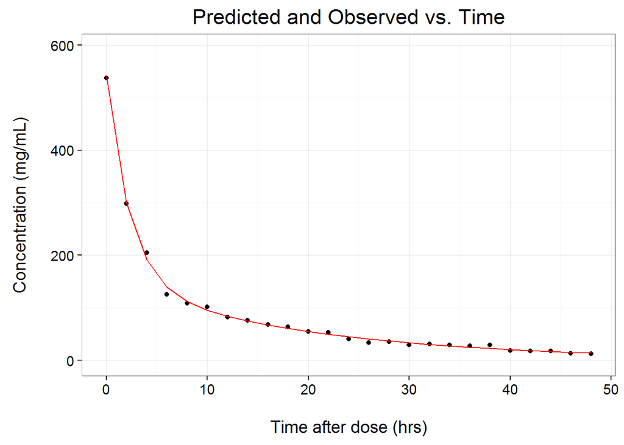

### Optimise Sampling Intervals

Using the exponential curve that best fits the data, the algorithm can determine the trapezoidal error given by a set of time intervals. From that the error can be minimised giving the optimal intervals.

```r
# Interval optimising function
  optim.interv <- function(times, fit.par) {
  # Order the times and determine min and max times so they can be fixed
    x <- times[order(times)]
    init.par <- x[-c(1, length(x))]
    xmin <- min(x)
    xmax <- max(x)
  # Determine whether the exponential parameters describe an absorption curve
    absorp <- ifelse((length(fit.par) %% 2) != 0, T, F)
  # Determine optimal sampling intervals by minimising trapezoidal error
  # Boundaries are ~1min above and below fixed min and max to improve stability
    res <- optim(
      init.par,
      err.interv,
      method = "L-BFGS-B", control = c(maxit = 500),
      lower = xmin, upper = xmax,
      exp.par = fit.par, tmin = xmin + 0.01, tmax = xmax - 0.01, a = absorp
    )
    return(res)
  }
```

As mentioned previously in the document, trapezoidal error can be approximated using the following equation.
$$\epsilon=\frac{(b-a)^3}{12}f''(\theta) \space \space \space \space{a \le \theta \le b}$$

This is implemented using the `err.interv` function below:

```r
  function(par, exp.par, tmin, tmax, a = F) {
  # Piece the times back together and determine the difference between them
    times <- c(tmin, par, tmax)
    deltat <- diff(times)
  # If exponential parameters describe an absorption curve
  # Determine the maximum second derivative of y for the beginning and end of
  # each interval
    if (a) {
      all.secd <- abs(pred.sumexp(exp.par, times, 2))
      secd <- c(NULL)
      for (i in 1:(length(times)-1)) {
        secd[i] <- all.secd[which(all.secd == max(all.secd[c(i, i + 1)]))]
      }
  # If exponential parameters describe a bolus curve
  # Use first value for second derivative as it will always be larger
    } else {
      secd <- pred.sumexp(exp.par, times[-length(times)], 2)
    }
  # Determine the sum of squared trapezoidal error
  # Sum of squares improves optim stability over using abs()
    err <- deltat^3*secd/12
    sum(err^2)
  }
```

The current implementation of determining trapezoidal error does not use $f''(\theta)$ as mentioned at the beginning of the document. Instead it observes the magnitude of error provided by $f''(a)$ and $f''(b)$. For the majority of intervals one of these second derivatives will be equal to $f''(\theta)$. Intervals where these values are not equal to $f''(\theta)$ are for absorption curves at times after the $C_{max}$.

Other than the issues with $f''(\theta)$ mentioned above this function:

- Does not account for errors seen when using linear-up, log-down trapezoidal method
  - Theoretically weighs the “log-down” concentrations more heavily than it should
  - Is this effect even important?

The result from using `optim.interv` can be seen below:

```
## $par
## [1]  1.098372  2.367679  3.885000  5.759870  8.185021 11.528991 16.511797
##
## $value
## [1] 467.9676
##
## $counts
## function gradient
##       34       34
##
## $convergence
## [1] 0
##
## $message
## [1] "CONVERGENCE: REL_REDUCTION_OF_F <= FACTR*EPSMCH"
```

This can be used to make a final output.

```
## $sumexpParameters
##          x1          x2          x3          x4
## -0.43232099 -0.04953696  5.97520375  4.99784161
##
## $optimisedInterval
## [1]  0.000000  1.098372  2.367679  3.885000  5.759870  8.185021 11.528991
## [8] 16.511797 24.000000
```

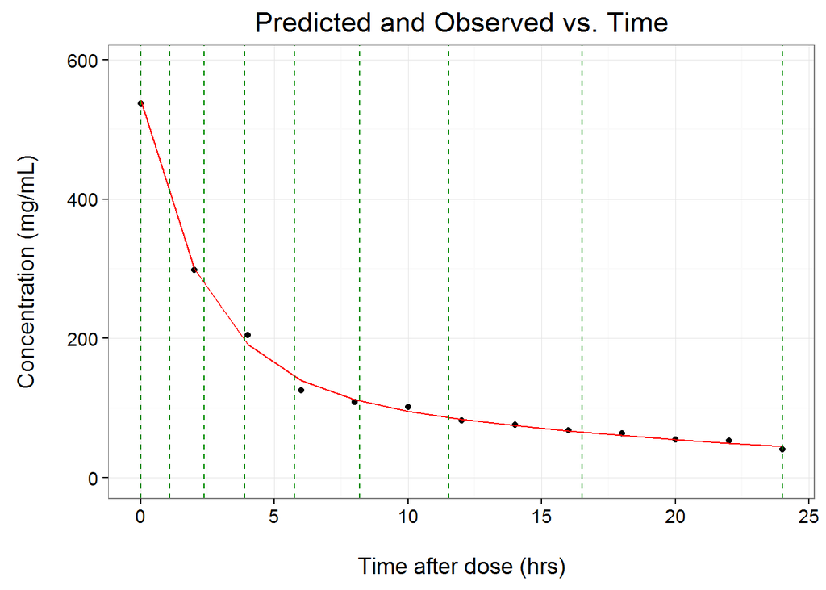

Example output for an absorption curve.

```
## $sumexpParameters
##          x1          x2          x3          x4          x5
## -0.09649901 -0.37065583 -0.26543898  3.79953979  3.18717898
##
## $optimisedInterval
## [1]  0.000000  2.379582  4.921909  7.920331 11.836399 19.746350 27.662948
## [8] 36.568662 48.000000
```

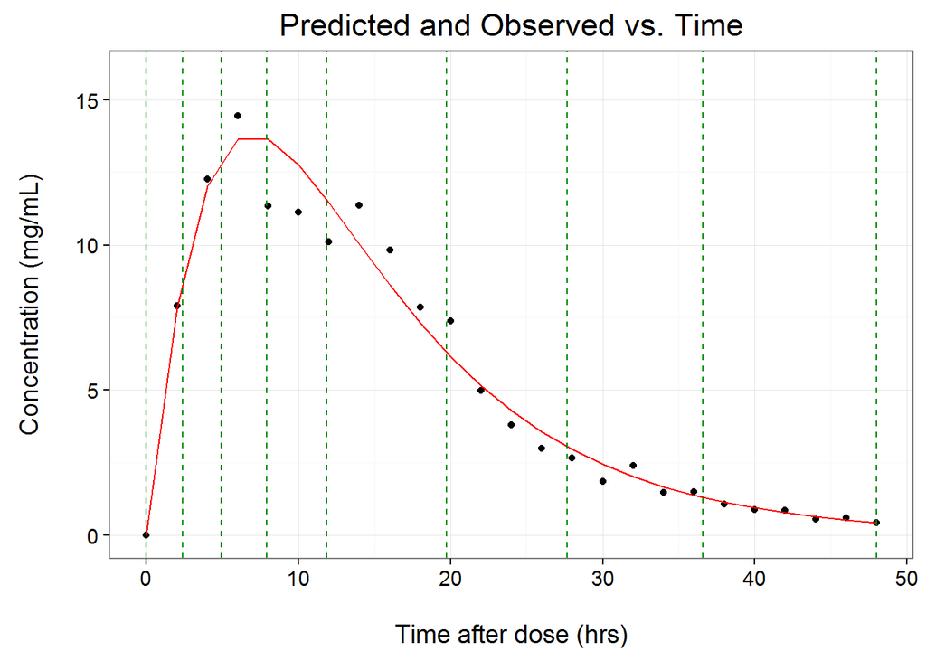